# ANOVA à 1 facteur

Séance 4 de *modèles linéaires

Florent Chuffart & Magali Richard

2019-02-14

# Organisation

## Pré-requis

- R https://cran.r-project.org
- RStudio https://www.rstudio.com

## Evaluation

- individuelle sur un jeu de données aprés 4 séances de cours
- data challenge à la fin des séances

## Supports

- https://github.com/magrichard/cours_modlin_M1

## Découpage prévisionnel

Séance 1 - 3h (10/01) Régression linéaire simple

Séance 2 - 3h (24/01) Régression linéaire multiple

Séance 3 - 3h (31/01) Anova 1 facteur / partie A

Séance 4 - 3h (14/02) Anova 1 facteur / partie B

Séance 5 - 3h (21/02) Anova 2 facteurs

Séance 6 - 3h (07/03) Anova multiple

Séance 7 - 3h (11/03) Anova facteurs emboités

Séance 8 - 3h (14/03) Ancova

# Plan

### ANOVA à 1 facteur

1. Rappels regression linéaire
2. Rappels ANOVA à un facteur
3. Test de l’ANOVA
4. Comparaisons multiples
5. Violation des conditions d’applicaition
6. Transformation des variables
7. Grandeur de l’effet expérimental
8. Facteurs à effets aléatoires

# I. Rappels regression linéaire

### Regression linéaire simple

**Objectif de la regression linéaire simple** Considérons $x$ et $Y$ deux variables quantitatives. Y est expliquée (modélisée) par la variable explicative $x$.

Modèle :
$$\widehat{Y} = E(Y) = f(x) = \beta_0 + \beta_1 x$$

$$Y_i = \beta_0 + \beta_1 x + e_i$$

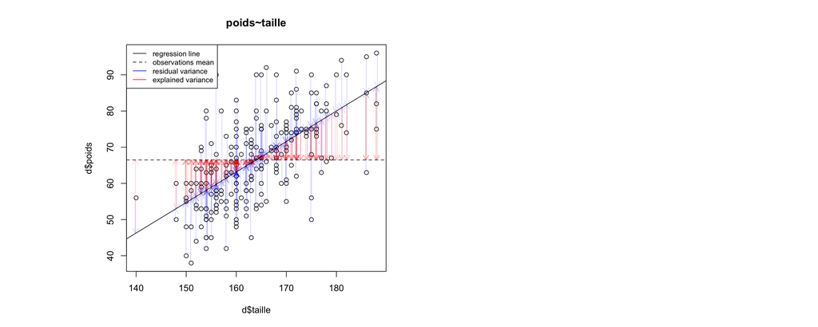

la méthode des *moindres carrés ordinaires (MCO)* minimise l’*erreur quadratique moyenne* (EQM, la somme du carré des résidus).

$$EQM(\beta_0, \beta_1) = \sum^{n}_{i=1} (Y_i - f(x_i))^2$$

La variance totale se décompose en la somme de la variance expliquée (par la regression) et la variance résiduelle.

$$\sum(Y_i - \overline{Y}_n)^2 = \sum(\widehat{Y}_i - \overline{Y}_n)^2 + \sum(Y_i - \widehat{Y}_i)^2$$

avec $Y_i$ la *i*-éme valeur observée pour $i=1,...,n$, $\widehat{Y}_i = f(x_i)$ la valeur estimée par le modèle pour $i=1,...,n$ et $\overline{Y}_n$ la moyenne empirique des $n$ observations.

$$SC_{tot} = SC_{reg} + SC_{res}$$

Avec $SC_{tot}$ la somme des carrés totale, $SC_{reg}$ la somme des carrés due à la régression et $SC_{res}$ la somme des carrés des résidus.

Le coefficient de determination $R^2$ mesure du pourcentage de la variance expliquée par le modèle.

$$R^2 = \frac{SC_{reg}}{SC_{tot}}$$

### Regression linéaire multiple

**Objectif de la regression linéaire multiple** Considérons $X_1, ..., X_p$ et $Y$ plusieurs variables quantitatives. Y est expliquée (modélisée) par les variable explicatives $X_1, ..., X_p$.

Modèle :

$$\widehat{Y} = \beta_0 + \beta_1X_1 + ... + \beta_pX_p + \epsilon$$

Utiliser les **moindres carrés** revient à minimiser la quantité suivante:

$$min_{\beta_0, ...,\beta_p}\sum^n_{i=1}\Big(y_i -(\beta_0+ \beta_1X_1 + ... + \beta_pX_p)\Big)^2$$

### Test statistique

**Test de Fisher**

On se pose la question de l’effet des variables $X$ :

$\mathcal{H}_0 : {\beta_1 = ... = \beta_p = 0}$ contre $\mathcal{H}_1 : \exists$ au moins un $j$ tel que ${\beta_j \neq 0}$ où $j$ varie de $1$ à $p$.

$$F_{obs} = \frac{CM_{reg}} {CM_{res}}$$
Nous décidons de rejeter l’hypothèse nulle $\mathcal{H}_0$ et d’accepter l’hypothèse alternative $\mathcal{H}_1$, au seuil $\alpha = 5\%$, si
$$|F_{obs}| \geq F_{1−\alpha,p−1,n−p}$$

**Test de Student**

On se pose la question de l’effet de la variable $x$ :

$\mathcal{H}_0 : {\beta_j = 0}$ contre $\mathcal{H}_1 : {\beta_j \neq 0}$ pour $j = 0, ..., p$

Si l’hypothese nulle $\mathcal{H}_0$ est vérifiée, alors la variable aléatoire $\mathcal{T}_{\widehat\beta_j,n-2} = \frac{\widehat\beta_j-0}{s_{\widehat\beta_j}}$ suit la loi de Student $\mathcal{T}(n-2)$

# II. Rappels ANOVA à un facteur

## Le modèle statistique

$$Y \sim X$$

*X* - L’analyse de la variance (ANOVA) se caractérise par des variables explicatives **qualitatives** (Ex : sexe, couleur des yeux).

*Y* - Dans les deux cas (ANOVA et regression linéaire) la variable expliquée est quantitative (Ex : taille, poids).

L’**ANOVA** à un facteur est un à la fois un **modèle** statistique fondé sur la décomposition de la variance et **test** statistique permettant de comparer les moyennes de plusieurs variables aléatoires indépendantes, gaussiennes et de même variance.

L’analyse de la variance est l’une des procédures les plus utilisées dans les applications de la statistique ainsi que dans les méthodes d’analyse de données.

### Exemple *InsectSprays*

```r
data("InsectSprays")
d = InsectSprays
head(d)
```

```
##   count spray
## 1    10     A
## 2     7     A
## 3    20     A
## 4    14     A
## 5    14     A
## 6    12     A
```

```r
tail(d)
```

```
##    count spray
## 67    13     F
## 68    10     F
## 69    26     F
## 70    26     F
## 71    24     F
## 72    13     F
```

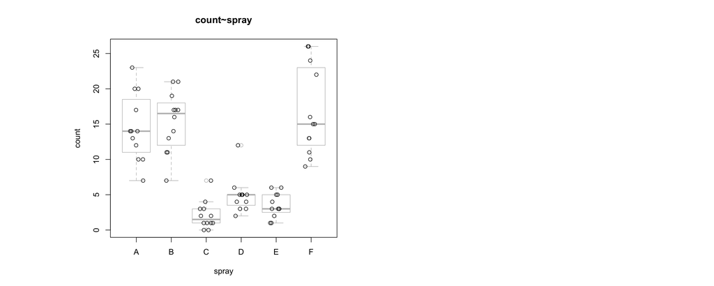

```r
layout(matrix(1:2, 1, byrow=TRUE), respect=TRUE)
p = plot(d$spray, d$count, main="count~spray", xlab="spray", ylab="count", border="grey")
points(jitter(as.numeric(d$spray)), d$count)
```

### L’ANOVA à un facteur, un modèle statistique

$$Y_{ij} = \mu + \alpha_i + \epsilon_{ij}$$

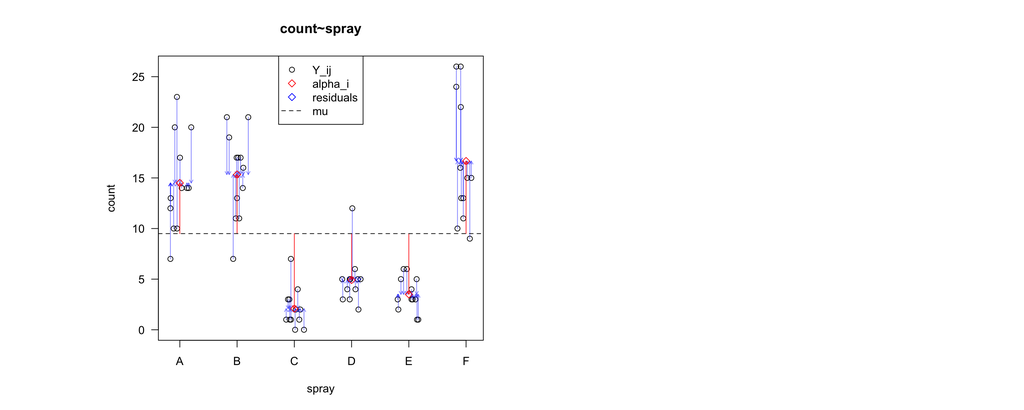

où :
$$\sum_{i=1}^I \alpha_i = 0$$

Ainsi :
$$\mu_i = \mu + \alpha_i, i=1,...,I$$

# III. Test de l’ANOVA

*Intuition* - Si l’hypothèse nulle $H_0$ est vraie alors la quantité $SC_F$ doit être petite par rapport à la quantité $SC_{res}$. Par contre, si l’hypothèse alternative $H_1$ est vraie alors la quantité $SC_F$ doit être grande par rapport à la quantité $SC_{res}$.

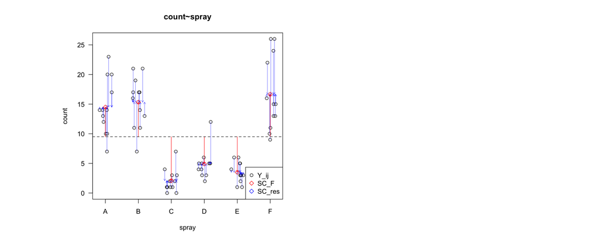

Pour comparer ces quantités, R. A. Fisher, après les avoir “corrigées” par leurs degrés de liberté (ddl), a considéré leur rapport.

Nous appelons *carré moyen associé au facteur* le terme

$$CM_F = \frac{SC_F}{I-1}$$

et *carré moyen résiduel* le terme :

$$CM_{res} = \frac{SC_{res}}{n-I}$$

Le carré moyen résiduel est un estimateur sans biais de la variance des erreurs $\sigma^2$. C’est pourquoi il est souvent également appelé variance résiduelle et presque systématiquement noté $S_{res}^2$ lorsqu’il sert à estimer la variance des erreurs. Sa valeur observée sur l’échantillon est ainsi notée $cm_{res}$ ou $s_{res}^2$ .

Si les trois conditions sont satisfaites et si l’hypothèse nulle $H_0$ est vraie alors

$$F_{obs} = \frac{cm_F}{cm_{res}}$$

est une réalisation d’une variable aléatoire F qui suit une loi de Fisher à $I-1$ degrés de liberté au numérateur et $n-I$ degrés de liberté au dénominateur. Cette loi est notée $\mathcal{F}_{I-1,n-I}$.

# III. Test de l’ANOVA

## Tableau de l’analyse de la variance

| Source de variation | sc | ddl | cm | $F_{obs}$ |
| --- | --- | --- | --- | --- |
| Due au facteur | $sc_{F}=\sum(\overline{y}_i-\overline{y}_n)^2$ | $I-1$ | $cm_{F}=\frac{sc_{F}}{I-1}$ | $\frac{cm_{F}}{cm_{res}}$ |
| Résiduelle | $sc_{res}=\sum(y_{ij}-\overline{y}_i)^2$ | $n-I$ | $cm_{res}=\frac{sc_{res}}{n-I}$ |  |
| Totale | $sc_{tot}=\sum(y_{ij}-\overline{y}_n)^2$ | $n-1$ |  |  |

# III. Test de l’ANOVA

## Test de l’ANOVA

### L’ANOVA à un facteur, un test de comparaison des moyennes

Sous certaines hypothèses, l’ANOVA devient un test de comparaison des moyennes des facteurs.

Ce test se fonde sur la décomposition de la variance.

$\mathcal{H}_0 : \mu_1 = \mu_2 = ... = \mu_I$ contre $\mathcal{H}_1$ : les moyennes $\mu_i$ ne sont pas toutes égales

Satistique du test: $F_{obs} = \frac{cm_{F}}{cm_{res}}$

Pour un seuil donné $\alpha$, les tables de Fisher nous fournissent une valeur critique $c$ telle que $\mathbb{P}_{H_0} [F \leq c] = 1 -\alpha$ Alors nous décidons :

- si $F_{obs} < c$, $\mathcal{H}_0$ est vraie,
- si $F_{obs} \geq c$, $\mathcal{H}_1$ est vraie,

### Hypothèses du test

Les résidus $\widehat{e_{ij}}$ sont associés, sans en être des réalisations, aux variables erreurs $\epsilon_{ij}$ qui sont inobservables et satisfont aux 3 conditions suivantes :

- Indépendance
- Normalité
- Homoscedasticité

# IV.Comparaisons multiples

Lorsque que nous rejettons $H_0$, nous pouvons chercher à analyser les **différences entre les groupes**. Nous procédons alors à des tests qui vont répondre à la question suivante :

D’où vient la différence ?

Quelles moyennes sont différentes ?

Ces tests qui vont répondre à cette question sont les tests de comparaisons multiples, des adaptations du test de Student.

Les méthodes de comparaison de moyennes à utiliser sont classées en comparaison *a priori* et *a posteriori*.

# IV.Comparaisons multiples

## Méthodes *a priori*

Avant de faire l’expérience, l’expérimentateur connaît la liste des hypothèses qu’il veut tester.

*Exemple* : montrer que les deux premiers laboratoires sont différents des deux autres.

Méthodes:

- Méthode de Bonferroni
- Méthode des contrastes linéaires (non détaillée)

# IV.Comparaisons multiples

## Méthode de Bonferroni

La plus connues est la correction de *Bonferroni*. Cela consiste à diviser le seuil par le nombre de comparaisons. Bonferroni a montré que cette procédure garantit un taux d’erreur global plus faible que le seuil initial.

**Objectif** : Comparer deux à deux toutes les moyennes possibles des $I$ groupes

1. Calculer le nombre de comparaisons : $n_c = (I \times (I- 1))/2$
2. Erreur de type I: $\alpha = 5\%$
3. Erreur pour chaque test : $\alpha' = 0.05/n_c$
4. Hypothèses : $\mathcal{H}_0 : \mu_i = \mu_j$ contre $\mathcal{H}_1 : \mu_i \neq \mu_j$
5. Statistique de test: $t_{obs} = \frac{\overline{y}_i-\overline{y}_j}{\sqrt{s^2_R}(\frac{1}{n_i}+\frac{1}{n_j})}$
6. Règle de décision : accepter $\mathcal{H}_0$ si $|t_{obs}| < t_{n-I;1-(\alpha'/2)}$

### Exemple *InsectSprays*

Illustrons la procédure précédente en comparant le **srpay B et le spray C**.

1. Nombre de comparaisons : $n_c = (6 \times (6- 1))/2 = 15$

```r
n = length(d$count)
I = length(levels(d$spray))
n_c = (I * (I-1))/2
print(n_c)
```

```
## [1] 15
```

2. Erreur de type I: $\alpha = 5\%$
3. Erreur pour chaque test : $\alpha' = 0.05/15 = 0.003$

```r
alpha = 0.05
alpha_prime = 0.05/n_c
print(alpha_prime)
```

```
## [1] 0.003333333
```

4. Hypothèses : $\mathcal{H}_0 : \mu_B = \mu_C$ contre $\mathcal{H}_1 : \mu_B \neq \mu_C$
5. Statistique de test: $t_{obs} = \frac{\overline{y}_i-\overline{y}_j}{\sqrt{s^2_R}(\frac{1}{n_i}+\frac{1}{n_j})}$

```r
table(d$spray)
```

```
##
##  A  B  C  D  E  F
## 12 12 12 12 12 12
```

```r
n_B = table(d$spray)[2]
print(n_B)
```

```
##  B
## 12
```

```r
n_C = table(d$spray)[3]
print(n_C)
```

```
##  C
## 12
```

```r
y_i = sapply(levels(d$spray), function(s) {
 mean(d[d$spray==s,]$count)
})
y_B = y_i[2]
print(y_B)
```

```
##        B
## 15.33333
```

```r
y_C = y_i[3]
print(y_C)
```

```
##        C
## 2.083333
```

```r
m = lm(d$count~d$spray)
anova(m)
```

```
## Analysis of Variance Table
##
## Response: d$count
##           Df Sum Sq Mean Sq F value    Pr(>F)
## d$spray    5 2668.8  533.77  34.702 < 2.2e-16 ***
## Residuals 66 1015.2   15.38
## ---
## Signif. codes:  0 '***' 0.001 '**' 0.01 '*' 0.05 '.' 0.1 ' ' 1
```

```r
s_2r = anova(m)[2,3] #cm_r est un estimateur sans biais de la variance des erreurs (variance résiduelle)
print(s_2r)
```

```
## [1] 15.38131
```

```r
t_obs = (y_B - y_C)/sqrt(s_2r*(1/n_B + 1/n_C))
print(t_obs)
```

```
##        B
## 8.275511
```

6. Règle de décision : accepter $\mathcal{H}_0$ si $|t_{obs}| < t_{n-I;1-(\alpha'/2)}$

```r
t_seuil = qt(p = (1-alpha_prime/2), df = (n-I))
print(t_seuil)
```

```
## [1] 3.045792
```

Nous rejetons $\mathcal{H}_0$ car $|t_{obs}| > t_{n-I;1-(\alpha'/2)}$

Regardons maintenant le **spray B et le spray A**.

```r
n = length(d$count)
I = length(levels(d$spray))
n_c = (I * (I-1))/2
print(n_c)
```

```
## [1] 15
```

2. Erreur de type I: $\alpha = 5\%$
3. Erreur pour chaque test : $\alpha' = 0.05/15 = 0.003$

```r
alpha = 0.05
alpha_prime = 0.05/n_c
print(alpha_prime)
```

```
## [1] 0.003333333
```

4. Hypothèses : $\mathcal{H}_0 : \mu_B = \mu_A$ contre $\mathcal{H}_1 : \mu_B \neq \mu_A$
5. Statistique de test: $t_{obs} = \frac{\overline{y}_i-\overline{y}_j}{\sqrt{s^2_R}(\frac{1}{n_i}+\frac{1}{n_j})}$

```r
table(d$spray)
```

```
##
##  A  B  C  D  E  F
## 12 12 12 12 12 12
```

```r
n_B = table(d$spray)[2]
print(n_B)
```

```
##  B
## 12
```

```r
n_A = table(d$spray)[1]
print(n_A)
```

```
##  A
## 12
```

```r
y_i = sapply(levels(d$spray), function(s) {
 mean(d[d$spray==s,]$count)
})
y_B = y_i[2]
print(y_B)
```

```
##        B
## 15.33333
```

```r
y_A = y_i[1]
print(y_A)
```

```
##    A
## 14.5
```

```r
m = lm(d$count~d$spray)
anova(m)
```

```
## Analysis of Variance Table
##
## Response: d$count
##           Df Sum Sq Mean Sq F value    Pr(>F)
## d$spray    5 2668.8  533.77  34.702 < 2.2e-16 ***
## Residuals 66 1015.2   15.38
## ---
## Signif. codes:  0 '***' 0.001 '**' 0.01 '*' 0.05 '.' 0.1 ' ' 1
```

```r
s_2r = anova(m)[2,3] #cm_r est un estimateur sans biais de la variance des erreurs (variance résiduelle)
print(s_2r)
```

```
## [1] 15.38131
```

```r
t_obs = (y_B - y_A)/sqrt(s_2r*(1/n_B + 1/n_A))
print(t_obs)
```

```
##         B
## 0.5204724
```

6. Règle de décision : accepter $\mathcal{H}_0$ si $|t_{obs}| < t_{n-I;1-(\alpha'/2)}$

```r
t_seuil = qt(p = (1-alpha_prime/2), df = (n-I))
print(t_seuil)
```

```
## [1] 3.045792
```

Nous conservons $\mathcal{H}_0$ car $|t_{obs}| < t_{n-I;1-(\alpha'/2)}$

[figure not shown]

# IV.Comparaisons multiples

## Méthodes *a posteriori*

Après l’expérience, l’expérimentateur regarde les résultats et oriente ses tests en fonction de ce qu’il observe dans les données.

**Exemple** : prendre la plus grande et la plus petite moyenne et tester si elles sont vraiment différentes.

Méthodes:

- Méthode basée sur la statistique de rang studentisée (non détaillée)
- Méthode de Newman Keuls (non détaillée)
- Méthode de Tukey HSD

# IV.Comparaisons multiples

## Méthode de Tukey HSD

Les moyennes observées $y_i$ sont rangées par ordre croissant. Nous rappelons que nous les notons
$$\overline{y}_1, \overline{y}_2,..., \overline{y}_I$$
et les moyennes théoriques associées
$$\mu_1, \mu_2,..., \mu_I$$

Pour chaque $i < i'$, nous considérons l’hypothèse nulle $\mathcal{H}_0 : \mu_i =\mu_{i'}$ contre l’hypothèse alternative $\mathcal{H}_1 : \mu_i' > \mu_{i}$.

Statistique de test: $t_{i',i, obs} = \frac{\overline{y}_{i'}-\overline{y}_j}{\sqrt{s^2_R}(\frac{1}{n_i'}+\frac{1}{n_i})}$

Le rapport $t_{i',i, obs}$ défini par ci-dessus est la réalisation d’une variable aléatoire $\mathcal{T}$ qui, si l’hypothèse nulle $\mathcal{H}_0$ est vraie, suit une loi appelée étendue studentisée (studentized range) et que nous notons $\mathcal{\widetilde{T}}_{n-I,I}$

Pour un seuil donné $\alpha$, les tables de l’étendue studentisée nous fournissent une valeur critique $c$ telle que $\mathbb{P}_{H_0} [T \leq c] = 1 -\alpha$ Alors nous décidons :

- si $t_{i',i, obs} < c$, $\mathcal{H}_0$ est vraie,
- si $t_{i',i, obs} \geq c$, $\mathcal{H}_1$ est vraie.

*Remarque*: La valeur critique $c$ ne dépend que des indices $n - I$, degrés de liberté de la somme des carrés résiduelle, et de $I$, nombre des moyennes comparées.

```r
m = aov(d$count~d$spray)
TukeyHSD(m)
```

```
##   Tukey multiple comparisons of means
##     95% family-wise confidence level
##
## Fit: aov(formula = d$count ~ d$spray)
##
## $`d$spray`
##            diff        lwr       upr     p adj
## B-A   0.8333333  -3.866075  5.532742 0.9951810
## C-A -12.4166667 -17.116075 -7.717258 0.0000000
## D-A  -9.5833333 -14.282742 -4.883925 0.0000014
## E-A -11.0000000 -15.699409 -6.300591 0.0000000
## F-A   2.1666667  -2.532742  6.866075 0.7542147
## C-B -13.2500000 -17.949409 -8.550591 0.0000000
## D-B -10.4166667 -15.116075 -5.717258 0.0000002
## E-B -11.8333333 -16.532742 -7.133925 0.0000000
## F-B   1.3333333  -3.366075  6.032742 0.9603075
## D-C   2.8333333  -1.866075  7.532742 0.4920707
## E-C   1.4166667  -3.282742  6.116075 0.9488669
## F-C  14.5833333   9.883925 19.282742 0.0000000
## E-D  -1.4166667  -6.116075  3.282742 0.9488669
## F-D  11.7500000   7.050591 16.449409 0.0000000
## F-E  13.1666667   8.467258 17.866075 0.0000000
```

- `diff` donne les différences entres les moyennes observées.
- `lwr` donne la borne inférieure de l’intervalle de confiance de la différence calculée
- `up` donne la borne supérieure de l’intervalle de confiance de la différence calculée
- `padj` donne la pvaleur après ajustement pour les comparaisons multiples

Si la valeur 0 n’est pas dans un intervalle, c’est que la différence correspondante peut être considérée comme significative

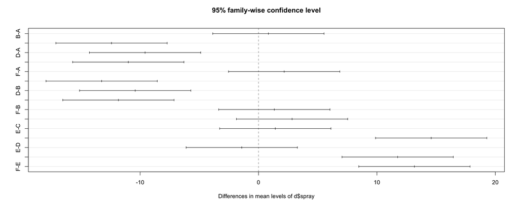

```r
plot(TukeyHSD(m))
```

# V. Violation des conditions d’application

Comme nous l’avons vu, l’analyse de la variance à un facteur se base sur les conditions d’application imposant:

1. l’indépendance des variables « erreurs »,
2. la normalité des variables « erreurs »,
3. l’homogénéité des variances des variables « erreurs ».

Les sujets doivent être répartis aléatoirement dans les groupes.

Enfreindre la condition d’application d’indépendance des variables « erreurs » nuit gravement à la santé de l’analyse de la variance.

Lorsque nous nous trouvons dans une situation où un même sujet aura subi plusieurs traitements, ou un même sujet aura été vu plusieurs fois, nous serons alors dans le cas où il faudra utiliser les plans à mesures répétées. Ce sujet sera traité dans un prochain chapitre.

# V. Violation des conditions d’application

## Normalité des variables erreurs

Il faut savoir que d’autres techniques statistiques existent lorsque la condition de normalité n’est pas vérifiée. Par exemple, nous pouvons envisager des transformations normalisantes.

## L’homogénéité des variables « erreurs »

D’autres techniques statistiques existent lorsque la condition d’homogénéité n’est pas vérifiée. Par exemple, Box (1954) a montré que dans le cas de variances hétérogènes, la distribution $\mathcal{F}$ adéquate à laquelle il faut comparer $\mathcal{F}_{obs}$ est une $\mathcal{F}$ régulière avec des ddl modifiés. Mais l’approche de Box présente un inconvénient majeur : elle est extrêmement conservatrice. Il existe toutefois des alternatives.

## Les alternatives

Welch (1951) a proposé une autre approche, que nous ne présenterons pas ici par manque de temps. Le lecteur intéressé par ce sujet pourra en première lecture ouvrir le livre de Howell (sixième édition) à la page 327, puis aller lire l’article original de Welch. Il est à noter que la procédure de Welch se trouve dans la plupart des logiciels statistiques. Enfin, à titre d’information, Wilcox (1987), dans son ouvrage « New statistical procedures for the social sciences » a un avis tranché sur les conséquences de l’hétérogénéité des variances. Il conseille d’utiliser la procédure de Welch, et en particulier lorsque les échantillons sont de tailles inégales.

Lorsque l’une des deux conditions (la condition de normalité des variables erreurs ou la condition d’homogénéité des variables erreurs) n’est pas vérifiée au moyen d’un test statistique, il faut s’assurer que cela n’est pas dû à une valeur extrême ou aberrante. Par exemple, pour savoir si une des valeurs recueillies n’est pas représentative, nous pouvons par exemple utiliser les tests de Grubbs ou de Dixon.